# EDASlides slides

[figure not shown]

## Exploratory Data Analysis (EDA)

*Jonathan | Jon | Ibrahim*

### Objectives

- Data Collection
- Data Cleaning
- Data Visualisation

### Data Collection

Data collection is the process of gathering information in an established systematic way that enables one to test hypothesis and evaluate outcomes easily.

```python
fifa = pd.read_csv('./DataSets/FIFA18.csv', low_memory=False)
```

```python
fifa.head()
```

|  | Unnamed: 0 | Name | Age | Photo | Nationality | Flag | Overall | Potential | Club | Club Logo | ... | RB | RCB | RCM | RDM | RF | RM | RS | RW | RWB | ST |
| --- | --- | --- | --- | --- | --- | --- | --- | --- | --- | --- | --- | --- | --- | --- | --- | --- | --- | --- | --- | --- | --- |
| 0 | 0 | Cristiano Ronaldo | 32 | https://cdn.sofifa.org/48/18/players/20801.png | Portugal | https://cdn.sofifa.org/flags/38.png | 94 | 94 | Real Madrid CF | https://cdn.sofifa.org/24/18/teams/243.png | ... | 61.0 | 53.0 | 82.0 | 62.0 | 91.0 | 89.0 | 92.0 | 91.0 | 66.0 | 92.0 |
| 1 | 1 | L. Messi | 30 | https://cdn.sofifa.org/48/18/players/158023.png | Argentina | https://cdn.sofifa.org/flags/52.png | 93 | 93 | FC Barcelona | https://cdn.sofifa.org/24/18/teams/241.png | ... | 57.0 | 45.0 | 84.0 | 59.0 | 92.0 | 90.0 | 88.0 | 91.0 | 62.0 | 88.0 |
| 2 | 2 | Neymar | 25 | https://cdn.sofifa.org/48/18/players/190871.png | Brazil | https://cdn.sofifa.org/flags/54.png | 92 | 94 | Paris Saint-Germain | https://cdn.sofifa.org/24/18/teams/73.png | ... | 59.0 | 46.0 | 79.0 | 59.0 | 88.0 | 87.0 | 84.0 | 89.0 | 64.0 | 84.0 |
| 3 | 3 | L. Suárez | 30 | https://cdn.sofifa.org/48/18/players/176580.png | Uruguay | https://cdn.sofifa.org/flags/60.png | 92 | 92 | FC Barcelona | https://cdn.sofifa.org/24/18/teams/241.png | ... | 64.0 | 58.0 | 80.0 | 65.0 | 88.0 | 85.0 | 88.0 | 87.0 | 68.0 | 88.0 |
| 4 | 4 | M. Neuer | 31 | https://cdn.sofifa.org/48/18/players/167495.png | Germany | https://cdn.sofifa.org/flags/21.png | 92 | 92 | FC Bayern Munich | https://cdn.sofifa.org/24/18/teams/21.png | ... | NaN | NaN | NaN | NaN | NaN | NaN | NaN | NaN | NaN | NaN |

5 rows × 75 columns

After getting data we need to check the data-type of features.

There are following types of features :

- numeric
- categorical
- ordinal
- datetime
- coordinates

In order to know the data types/features of data, we need to run:

```python
fifa.dtypes
```

```
Unnamed: 0               int64
Name                    object
Age                      int64
Photo                   object
Nationality             object
Flag                    object
Overall                  int64
Potential                int64
Club                    object
Club Logo               object
Value                   object
Wage                    object
Special                  int64
Acceleration            object
Aggression              object
Agility                 object
Balance                 object
Ball control            object
Composure               object
Crossing                object
Curve                   object
Dribbling               object
Finishing               object
Free kick accuracy      object
GK diving               object
GK handling             object
GK kicking              object
GK positioning          object
GK reflexes             object
Heading accuracy        object
                        ...
Vision                  object
Volleys                 object
CAM                    float64
CB                     float64
CDM                    float64
CF                     float64
CM                     float64
ID                       int64
LAM                    float64
LB                     float64
LCB                    float64
LCM                    float64
LDM                    float64
LF                     float64
LM                     float64
LS                     float64
LW                     float64
LWB                    float64
Preferred Positions     object
RAM                    float64
RB                     float64
RCB                    float64
RCM                    float64
RDM                    float64
RF                     float64
RM                     float64
RS                     float64
RW                     float64
RWB                    float64
ST                     float64
Length: 75, dtype: object
```

```python
fifa.info()
```

```
<class 'pandas.core.frame.DataFrame'>
RangeIndex: 17981 entries, 0 to 17980
Data columns (total 75 columns):
Unnamed: 0             17981 non-null int64
Name                   17981 non-null object
Age                    17981 non-null int64
Photo                  17981 non-null object
Nationality            17981 non-null object
Flag                   17981 non-null object
Overall                17981 non-null int64
Potential              17981 non-null int64
Club                   17733 non-null object
Club Logo              17981 non-null object
Value                  17981 non-null object
Wage                   17981 non-null object
Special                17981 non-null int64
Acceleration           17981 non-null object
Aggression             17981 non-null object
Agility                17981 non-null object
Balance                17981 non-null object
Ball control           17981 non-null object
Composure              17981 non-null object
Crossing               17981 non-null object
Curve                  17981 non-null object
Dribbling              17981 non-null object
Finishing              17981 non-null object
Free kick accuracy     17981 non-null object
GK diving              17981 non-null object
GK handling            17981 non-null object
GK kicking             17981 non-null object
GK positioning         17981 non-null object
GK reflexes            17981 non-null object
Heading accuracy       17981 non-null object
Interceptions          17981 non-null object
Jumping                17981 non-null object
Long passing           17981 non-null object
Long shots             17981 non-null object
Marking                17981 non-null object
Penalties              17981 non-null object
Positioning            17981 non-null object
```

[output cut: 25 more lines]

```
LWB                    15952 non-null float64
Preferred Positions    17981 non-null object
RAM                    15952 non-null float64
RB                     15952 non-null float64
RCB                    15952 non-null float64
RCM                    15952 non-null float64
RDM                    15952 non-null float64
RF                     15952 non-null float64
RM                     15952 non-null float64
RS                     15952 non-null float64
RW                     15952 non-null float64
RWB                    15952 non-null float64
ST                     15952 non-null float64
dtypes: float64(26), int64(6), object(43)
memory usage: 10.3+ MB
```

### Data Cleaning

High-level, data types are a way of storing data that can be utilized for different purposes. For our arithmetic and visualization purposes, we want to change the datatypes to floats or integers that will allow subsequent mathematical processes to be run on them.

```python
'''
From our initial dataset read through, we can determine that wage is returned as an object data type, but
it should be a float or integer, so it warrants further inspection.
'''

fifa.Wage.head()
```

```
0    €565K
1    €565K
2    €280K
3    €510K
4    €230K
Name: Wage, dtype: object
```

```python
def remove_currency(data_column):
    '''
    We can see from the above that we need to from replace €, K from data column and convert to int.

    We can do so using this function.
    '''
    data_column = data_column.str.replace('€', '')
    data_column = data_column.str.replace('K', '')
    data_column = pd.to_numeric(data_column)
    return data_column
```

```python
'''
Here we call the above function on this Wage column.
'''

fifa["Wage"] = remove_currency(fifa["Wage"])
```

```python
'''
Here we check that the symbols have been removed.
'''

fifa.Wage.head()
```

```
0    565
1    565
2    280
3    510
4    230
Name: Wage, dtype: int64
```

```python
fifa.info()
```

```
<class 'pandas.core.frame.DataFrame'>
RangeIndex: 17981 entries, 0 to 17980
Data columns (total 75 columns):
Unnamed: 0             17981 non-null int64
Name                   17981 non-null object
Age                    17981 non-null int64
Photo                  17981 non-null object
Nationality            17981 non-null object
Flag                   17981 non-null object
Overall                17981 non-null int64
Potential              17981 non-null int64
Club                   17733 non-null object
Club Logo              17981 non-null object
Value                  17981 non-null object
Wage                   17981 non-null int64
Special                17981 non-null int64
Acceleration           17981 non-null object
Aggression             17981 non-null object
Agility                17981 non-null object
Balance                17981 non-null object
Ball control           17981 non-null object
Composure              17981 non-null object
Crossing               17981 non-null object
Curve                  17981 non-null object
Dribbling              17981 non-null object
Finishing              17981 non-null object
Free kick accuracy     17981 non-null object
GK diving              17981 non-null object
GK handling            17981 non-null object
GK kicking             17981 non-null object
GK positioning         17981 non-null object
GK reflexes            17981 non-null object
Heading accuracy       17981 non-null object
Interceptions          17981 non-null object
Jumping                17981 non-null object
Long passing           17981 non-null object
Long shots             17981 non-null object
Marking                17981 non-null object
Penalties              17981 non-null object
Positioning            17981 non-null object
```

[output cut: 25 more lines]

```
LWB                    15952 non-null float64
Preferred Positions    17981 non-null object
RAM                    15952 non-null float64
RB                     15952 non-null float64
RCB                    15952 non-null float64
RCM                    15952 non-null float64
RDM                    15952 non-null float64
RF                     15952 non-null float64
RM                     15952 non-null float64
RS                     15952 non-null float64
RW                     15952 non-null float64
RWB                    15952 non-null float64
ST                     15952 non-null float64
dtypes: float64(26), int64(7), object(42)
memory usage: 10.3+ MB
```

```python
'''
We can now observe that value needs the same treatment
'''

fifa.Value.head()
```

```
0    €95.5M
1     €105M
2     €123M
3      €97M
4      €61M
Name: Value, dtype: object
```

```python
def remove_currency_mill(data_column):
    data_column = data_column.str.replace('€', '')
    data_column = data_column.str.replace('M', '')
    data_column = data_column.str.replace('K', '')
    data_column = pd.to_numeric(data_column)
    return data_column
```

```python
fifa["Value"] = remove_currency_mill(fifa["Value"])
```

```python
fifa.info()
```

```
<class 'pandas.core.frame.DataFrame'>
RangeIndex: 17981 entries, 0 to 17980
Data columns (total 75 columns):
Unnamed: 0             17981 non-null int64
Name                   17981 non-null object
Age                    17981 non-null int64
Photo                  17981 non-null object
Nationality            17981 non-null object
Flag                   17981 non-null object
Overall                17981 non-null int64
Potential              17981 non-null int64
Club                   17733 non-null object
Club Logo              17981 non-null object
Value                  17981 non-null float64
Wage                   17981 non-null int64
Special                17981 non-null int64
Acceleration           17981 non-null object
Aggression             17981 non-null object
Agility                17981 non-null object
Balance                17981 non-null object
Ball control           17981 non-null object
Composure              17981 non-null object
Crossing               17981 non-null object
Curve                  17981 non-null object
Dribbling              17981 non-null object
Finishing              17981 non-null object
Free kick accuracy     17981 non-null object
GK diving              17981 non-null object
GK handling            17981 non-null object
GK kicking             17981 non-null object
GK positioning         17981 non-null object
GK reflexes            17981 non-null object
Heading accuracy       17981 non-null object
Interceptions          17981 non-null object
Jumping                17981 non-null object
Long passing           17981 non-null object
Long shots             17981 non-null object
Marking                17981 non-null object
Penalties              17981 non-null object
Positioning            17981 non-null object
```

[output cut: 25 more lines]

```
LWB                    15952 non-null float64
Preferred Positions    17981 non-null object
RAM                    15952 non-null float64
RB                     15952 non-null float64
RCB                    15952 non-null float64
RCM                    15952 non-null float64
RDM                    15952 non-null float64
RF                     15952 non-null float64
RM                     15952 non-null float64
RS                     15952 non-null float64
RW                     15952 non-null float64
RWB                    15952 non-null float64
ST                     15952 non-null float64
dtypes: float64(27), int64(7), object(41)
memory usage: 10.3+ MB
```

We can use the describe function to provide more information on the data.

- describe() function shows the statistics of the data.
- If you try running this with columns that do not have all integers or floats, then the column data will not be displayed.
- It can be very useful to look at these statistics early on to get high level idea about the data.

```python
fifa.describe().T
```

|  | count | mean | std | min | 25% | 50% | 75% | max |
| --- | --- | --- | --- | --- | --- | --- | --- | --- |
| Unnamed: 0 | 17981.0 | 8990.000000 | 5190.811931 | 0.0 | 4495.0 | 8990.0 | 13485.0 | 17980.0 |
| Age | 17981.0 | 25.144541 | 4.614272 | 16.0 | 21.0 | 25.0 | 28.0 | 47.0 |
| Overall | 17981.0 | 66.247984 | 6.987965 | 46.0 | 62.0 | 66.0 | 71.0 | 94.0 |
| Potential | 17981.0 | 71.190813 | 6.102199 | 46.0 | 67.0 | 71.0 | 75.0 | 94.0 |
| Value | 17981.0 | 260.810316 | 288.430164 | 0.0 | 4.3 | 150.0 | 475.0 | 975.0 |
| Wage | 17981.0 | 11.546966 | 23.080000 | 0.0 | 2.0 | 4.0 | 12.0 | 565.0 |
| Special | 17981.0 | 1594.095100 | 272.151435 | 728.0 | 1449.0 | 1633.0 | 1786.0 | 2291.0 |
| CAM | 15952.0 | 59.251755 | 9.880164 | 27.0 | 53.0 | 60.0 | 66.0 | 92.0 |
| CB | 15952.0 | 55.550464 | 12.192579 | 25.0 | 45.0 | 57.0 | 65.0 | 87.0 |
| CDM | 15952.0 | 56.865283 | 10.310178 | 26.0 | 49.0 | 58.0 | 65.0 | 85.0 |
| CF | 15952.0 | 59.030028 | 9.926988 | 27.0 | 53.0 | 60.0 | 66.0 | 92.0 |
| CM | 15952.0 | 58.506833 | 8.888040 | 30.0 | 53.0 | 59.0 | 65.0 | 87.0 |
| ID | 17981.0 | 207658.710138 | 32291.667313 | 16.0 | 192622.0 | 214057.0 | 231448.0 | 241219.0 |
| LAM | 15952.0 | 59.251755 | 9.880164 | 27.0 | 53.0 | 60.0 | 66.0 | 92.0 |
| LB | 15952.0 | 56.979689 | 9.791627 | 30.0 | 50.0 | 58.0 | 64.0 | 84.0 |
| LCB | 15952.0 | 55.550464 | 12.192579 | 25.0 | 45.0 | 57.0 | 65.0 | 87.0 |
| LCM | 15952.0 | 58.506833 | 8.888040 | 30.0 | 53.0 | 59.0 | 65.0 | 87.0 |
| LDM | 15952.0 | 56.865283 | 10.310178 | 26.0 | 49.0 | 58.0 | 65.0 | 85.0 |
| LF | 15952.0 | 59.030028 | 9.926988 | 27.0 | 53.0 | 60.0 | 66.0 | 92.0 |
| LM | 15952.0 | 60.057736 | 9.349180 | 28.0 | 54.0 | 61.0 | 67.0 | 90.0 |
| LS | 15952.0 | 58.204050 | 9.181392 | 31.0 | 52.0 | 59.0 | 65.0 | 92.0 |
| LW | 15952.0 | 59.359265 | 9.978084 | 26.0 | 53.0 | 60.0 | 66.0 | 91.0 |
| LWB | 15952.0 | 57.698721 | 9.142825 | 31.0 | 51.0 | 58.0 | 64.0 | 84.0 |
| RAM | 15952.0 | 59.251755 | 9.880164 | 27.0 | 53.0 | 60.0 | 66.0 | 92.0 |
| RB | 15952.0 | 56.979689 | 9.791627 | 30.0 | 50.0 | 58.0 | 64.0 | 84.0 |
| RCB | 15952.0 | 55.550464 | 12.192579 | 25.0 | 45.0 | 57.0 | 65.0 | 87.0 |
| RCM | 15952.0 | 58.506833 | 8.888040 | 30.0 | 53.0 | 59.0 | 65.0 | 87.0 |
| RDM | 15952.0 | 56.865283 | 10.310178 | 26.0 | 49.0 | 58.0 | 65.0 | 85.0 |
| RF | 15952.0 | 59.030028 | 9.926988 | 27.0 | 53.0 | 60.0 | 66.0 | 92.0 |
| RM | 15952.0 | 60.057736 | 9.349180 | 28.0 | 54.0 | 61.0 | 67.0 | 90.0 |
| RS | 15952.0 | 58.204050 | 9.181392 | 31.0 | 52.0 | 59.0 | 65.0 | 92.0 |
| RW | 15952.0 | 59.359265 | 9.978084 | 26.0 | 53.0 | 60.0 | 66.0 | 91.0 |
| RWB | 15952.0 | 57.698721 | 9.142825 | 31.0 | 51.0 | 58.0 | 64.0 | 84.0 |
| ST | 15952.0 | 58.204050 | 9.181392 | 31.0 | 52.0 | 59.0 | 65.0 | 92.0 |

from the above we can observe a couple of columns that could use more cleaning/investigation.

1. the unnamed: 0 column appears to be another index row, which is not required as the data frame has applied an automatic index.
2. row ID has a minimum alot lower than the IQR.

```python
fifa.drop('Unnamed: 0', axis = 1, inplace=True)
```

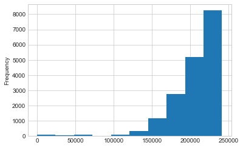

```python
fifa.ID.plot.hist()
```

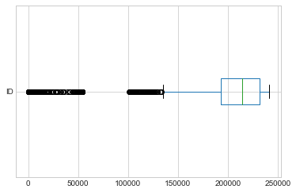

```python
fifa.ID.plot.box(vert = False)
```

We need to decide whether we want to remove the outliers from this dataset prior to visualisation, or whether we come back to it after we have had an opportunity to look for any potential relationships between data points.

### Data Visualizations

- Charts or graphs that visualize large amounts of complex data are easier to understand than spreadsheets or reports.
- Data visualization is a quick, easy way to convey concepts in a universal manner

```python
fifa.corr()
```

|  | Age | Overall | Potential | Value | Wage | Special | CAM | CB | CDM | CF | ... | RB | RCB | RCM | RDM | RF | RM | RS | RW | RWB | ST |
| --- | --- | --- | --- | --- | --- | --- | --- | --- | --- | --- | --- | --- | --- | --- | --- | --- | --- | --- | --- | --- | --- |
| Age | 1.000000 | 0.459765 | -0.218264 | -0.067069 | 0.150006 | 0.238667 | 0.245855 | 0.337481 | 0.383450 | 0.235596 | ... | 0.321227 | 0.337481 | 0.365783 | 0.383450 | 0.235596 | 0.232945 | 0.287541 | 0.206051 | 0.337143 | 0.287541 |
| Overall | 0.459765 | 1.000000 | 0.683474 | -0.233466 | 0.593789 | 0.604092 | 0.650313 | 0.448856 | 0.607727 | 0.636278 | ... | 0.561887 | 0.448856 | 0.764609 | 0.607727 | 0.636278 | 0.656745 | 0.664822 | 0.610198 | 0.629401 | 0.664822 |
| Potential | -0.218264 | 0.683474 | 1.000000 | -0.217572 | 0.519062 | 0.399511 | 0.470421 | 0.219380 | 0.345344 | 0.458830 | ... | 0.330672 | 0.219380 | 0.508133 | 0.345344 | 0.458830 | 0.474998 | 0.447747 | 0.448580 | 0.383213 | 0.447747 |
| Value | -0.067069 | -0.233466 | -0.217572 | 1.000000 | -0.261942 | -0.109017 | -0.181998 | -0.093359 | -0.139879 | -0.180572 | ... | -0.125827 | -0.093359 | -0.203486 | -0.139879 | -0.180572 | -0.177024 | -0.184606 | -0.169072 | -0.144693 | -0.184606 |
| Wage | 0.150006 | 0.593789 | 0.519062 | -0.261942 | 1.000000 | 0.367419 | 0.412427 | 0.220554 | 0.321822 | 0.408102 | ... | 0.299300 | 0.220554 | 0.457183 | 0.321822 | 0.408102 | 0.412422 | 0.421092 | 0.390940 | 0.343395 | 0.421092 |
| Special | 0.238667 | 0.604092 | 0.399511 | -0.109017 | 0.367419 | 1.000000 | 0.854197 | 0.401629 | 0.650723 | 0.822487 | ... | 0.623048 | 0.401629 | 0.943764 | 0.650723 | 0.822487 | 0.872130 | 0.793552 | 0.825615 | 0.735167 | 0.793552 |
| CAM | 0.245855 | 0.650313 | 0.470421 | -0.181998 | 0.412427 | 0.854197 | 1.000000 | -0.070694 | 0.257182 | 0.986346 | ... | 0.204500 | -0.070694 | 0.903315 | 0.257182 | 0.986346 | 0.983408 | 0.927452 | 0.983941 | 0.368896 | 0.927452 |
| CB | 0.337481 | 0.448856 | 0.219380 | -0.093359 | 0.220554 | 0.401629 | -0.070694 | 1.000000 | 0.929486 | -0.141250 | ... | 0.926170 | 1.000000 | 0.328064 | 0.929486 | -0.141250 | -0.029624 | -0.129200 | -0.139745 | 0.849959 | -0.129200 |
| CDM | 0.383450 | 0.607727 | 0.345344 | -0.139879 | 0.321822 | 0.650723 | 0.257182 | 0.929486 | 1.000000 | 0.165728 | ... | 0.968022 | 0.929486 | 0.631197 | 1.000000 | 0.165728 | 0.292332 | 0.129067 | 0.175801 | 0.955188 | 0.129067 |
| CF | 0.235596 | 0.636278 | 0.458830 | -0.180572 | 0.408102 | 0.822487 | 0.986346 | -0.141250 | 0.165728 | 1.000000 | ... | 0.123218 | -0.141250 | 0.846493 | 0.165728 | 1.000000 | 0.970136 | 0.967872 | 0.986833 | 0.286582 | 0.967872 |
| CM | 0.365783 | 0.764609 | 0.508133 | -0.203486 | 0.457183 | 0.943764 | 0.903315 | 0.328064 | 0.631197 | 0.846493 | ... | 0.558706 | 0.328064 | 1.000000 | 0.631197 | 0.846493 | 0.898170 | 0.779877 | 0.844640 | 0.685704 | 0.779877 |
| ID | -0.719316 | -0.425881 | 0.001998 | 0.088663 | -0.213480 | -0.232074 | -0.268760 | -0.285998 | -0.345803 | -0.254976 | ... | -0.282252 | -0.285998 | -0.367868 | -0.345803 | -0.254976 | -0.250306 | -0.291824 | -0.229243 | -0.304484 | -0.291824 |
| LAM | 0.245855 | 0.650313 | 0.470421 | -0.181998 | 0.412427 | 0.854197 | 1.000000 | -0.070694 | 0.257182 | 0.986346 | ... | 0.204500 | -0.070694 | 0.903315 | 0.257182 | 0.986346 | 0.983408 | 0.927452 | 0.983941 | 0.368896 | 0.927452 |
| LB | 0.321227 | 0.561887 | 0.330672 | -0.125827 | 0.299300 | 0.623048 | 0.204500 | 0.926170 | 0.968022 | 0.123218 | ... | 1.000000 | 0.926170 | 0.558706 | 0.968022 | 0.123218 | 0.273691 | 0.077723 | 0.158306 | 0.981366 | 0.077723 |
| LCB | 0.337481 | 0.448856 | 0.219380 | -0.093359 | 0.220554 | 0.401629 | -0.070694 | 1.000000 | 0.929486 | -0.141250 | ... | 0.926170 | 1.000000 | 0.328064 | 0.929486 | -0.141250 | -0.029624 | -0.129200 | -0.139745 | 0.849959 | -0.129200 |
| LCM | 0.365783 | 0.764609 | 0.508133 | -0.203486 | 0.457183 | 0.943764 | 0.903315 | 0.328064 | 0.631197 | 0.846493 | ... | 0.558706 | 0.328064 | 1.000000 | 0.631197 | 0.846493 | 0.898170 | 0.779877 | 0.844640 | 0.685704 | 0.779877 |
| LDM | 0.383450 | 0.607727 | 0.345344 | -0.139879 | 0.321822 | 0.650723 | 0.257182 | 0.929486 | 1.000000 | 0.165728 | ... | 0.968022 | 0.929486 | 0.631197 | 1.000000 | 0.165728 | 0.292332 | 0.129067 | 0.175801 | 0.955188 | 0.129067 |
| LF | 0.235596 | 0.636278 | 0.458830 | -0.180572 | 0.408102 | 0.822487 | 0.986346 | -0.141250 | 0.165728 | 1.000000 | ... | 0.123218 | -0.141250 | 0.846493 | 0.165728 | 1.000000 | 0.970136 | 0.967872 | 0.986833 | 0.286582 | 0.967872 |
| LM | 0.232945 | 0.656745 | 0.474998 | -0.177024 | 0.412422 | 0.872130 | 0.983408 | -0.029624 | 0.292332 | 0.970136 | ... | 0.273691 | -0.029624 | 0.898170 | 0.292332 | 0.970136 | 1.000000 | 0.900747 | 0.988587 | 0.439558 | 0.900747 |
| LS | 0.287541 | 0.664822 | 0.447747 | -0.184606 | 0.421092 | 0.793552 | 0.927452 | -0.129200 | 0.129067 | 0.967872 | ... | 0.077723 | -0.129200 | 0.779877 | 0.129067 | 0.967872 | 0.900747 | 1.000000 | 0.929186 | 0.222406 | 1.000000 |
| LW | 0.206051 | 0.610198 | 0.448580 | -0.169072 | 0.390940 | 0.825615 | 0.983941 | -0.139745 | 0.175801 | 0.986833 | ... | 0.158306 | -0.139745 | 0.844640 | 0.175801 | 0.986833 | 0.988587 | 0.929186 | 1.000000 | 0.327975 | 0.929186 |
| LWB | 0.337143 | 0.629401 | 0.383213 | -0.144693 | 0.343395 | 0.735167 | 0.368896 | 0.849959 | 0.955188 | 0.286582 | ... | 0.981366 | 0.849959 | 0.685704 | 0.955188 | 0.286582 | 0.439558 | 0.222406 | 0.327975 | 1.000000 | 0.222406 |
| RAM | 0.245855 | 0.650313 | 0.470421 | -0.181998 | 0.412427 | 0.854197 | 1.000000 | -0.070694 | 0.257182 | 0.986346 | ... | 0.204500 | -0.070694 | 0.903315 | 0.257182 | 0.986346 | 0.983408 | 0.927452 | 0.983941 | 0.368896 | 0.927452 |
| RB | 0.321227 | 0.561887 | 0.330672 | -0.125827 | 0.299300 | 0.623048 | 0.204500 | 0.926170 | 0.968022 | 0.123218 | ... | 1.000000 | 0.926170 | 0.558706 | 0.968022 | 0.123218 | 0.273691 | 0.077723 | 0.158306 | 0.981366 | 0.077723 |
| RCB | 0.337481 | 0.448856 | 0.219380 | -0.093359 | 0.220554 | 0.401629 | -0.070694 | 1.000000 | 0.929486 | -0.141250 | ... | 0.926170 | 1.000000 | 0.328064 | 0.929486 | -0.141250 | -0.029624 | -0.129200 | -0.139745 | 0.849959 | -0.129200 |
| RCM | 0.365783 | 0.764609 | 0.508133 | -0.203486 | 0.457183 | 0.943764 | 0.903315 | 0.328064 | 0.631197 | 0.846493 | ... | 0.558706 | 0.328064 | 1.000000 | 0.631197 | 0.846493 | 0.898170 | 0.779877 | 0.844640 | 0.685704 | 0.779877 |
| RDM | 0.383450 | 0.607727 | 0.345344 | -0.139879 | 0.321822 | 0.650723 | 0.257182 | 0.929486 | 1.000000 | 0.165728 | ... | 0.968022 | 0.929486 | 0.631197 | 1.000000 | 0.165728 | 0.292332 | 0.129067 | 0.175801 | 0.955188 | 0.129067 |
| RF | 0.235596 | 0.636278 | 0.458830 | -0.180572 | 0.408102 | 0.822487 | 0.986346 | -0.141250 | 0.165728 | 1.000000 | ... | 0.123218 | -0.141250 | 0.846493 | 0.165728 | 1.000000 | 0.970136 | 0.967872 | 0.986833 | 0.286582 | 0.967872 |
| RM | 0.232945 | 0.656745 | 0.474998 | -0.177024 | 0.412422 | 0.872130 | 0.983408 | -0.029624 | 0.292332 | 0.970136 | ... | 0.273691 | -0.029624 | 0.898170 | 0.292332 | 0.970136 | 1.000000 | 0.900747 | 0.988587 | 0.439558 | 0.900747 |
| RS | 0.287541 | 0.664822 | 0.447747 | -0.184606 | 0.421092 | 0.793552 | 0.927452 | -0.129200 | 0.129067 | 0.967872 | ... | 0.077723 | -0.129200 | 0.779877 | 0.129067 | 0.967872 | 0.900747 | 1.000000 | 0.929186 | 0.222406 | 1.000000 |
| RW | 0.206051 | 0.610198 | 0.448580 | -0.169072 | 0.390940 | 0.825615 | 0.983941 | -0.139745 | 0.175801 | 0.986833 | ... | 0.158306 | -0.139745 | 0.844640 | 0.175801 | 0.986833 | 0.988587 | 0.929186 | 1.000000 | 0.327975 | 0.929186 |
| RWB | 0.337143 | 0.629401 | 0.383213 | -0.144693 | 0.343395 | 0.735167 | 0.368896 | 0.849959 | 0.955188 | 0.286582 | ... | 0.981366 | 0.849959 | 0.685704 | 0.955188 | 0.286582 | 0.439558 | 0.222406 | 0.327975 | 1.000000 | 0.222406 |
| ST | 0.287541 | 0.664822 | 0.447747 | -0.184606 | 0.421092 | 0.793552 | 0.927452 | -0.129200 | 0.129067 | 0.967872 | ... | 0.077723 | -0.129200 | 0.779877 | 0.129067 | 0.967872 | 0.900747 | 1.000000 | 0.929186 | 0.222406 | 1.000000 |

33 rows × 33 columns

```
Text(0.5,1,'Age/Wage')
```

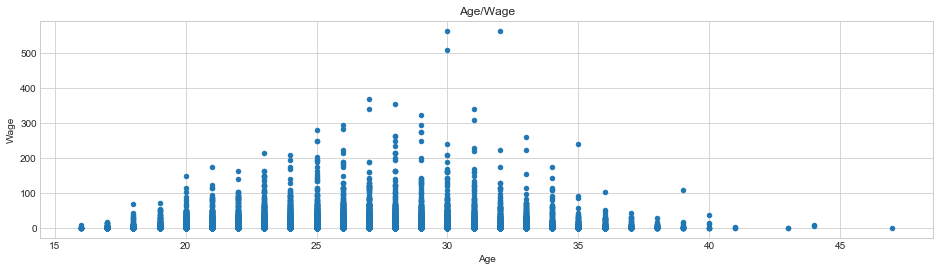

```python
ax = fifa.plot.scatter('Age', 'Wage', figsize=(16,4))
ax.set_title("Age/Wage")
```

- Data visualization is a quick, easy way to convey concepts in a universal manner

# Types of Plot

- Univariate
- Bivariate
- Multivariate

### Univariate

- 'line' : line plot (default)
- 'bar' : vertical bar plot
- 'pie' : pie plot
- 'barh' : horizontal bar plot
- 'hist' : histogram
- 'area' : area plot

# Line, Area

- Good for ordinal categorical and interval data.
- Line graphs are used to track changes over short and long periods of time.
- Line graphs can also be used to compare changes over the same period of time for more than one group.

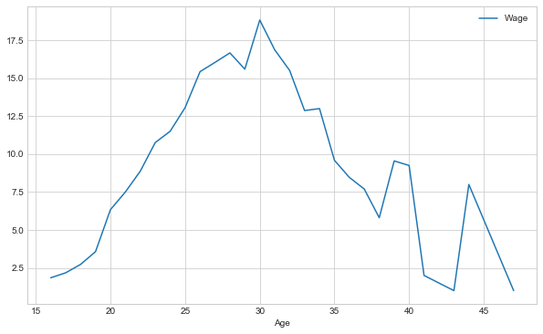

```python
# 'line' : line plot (default)

fifa.groupby(by='Age').mean()[['Wage']].plot.line(figsize=(10,6))
```

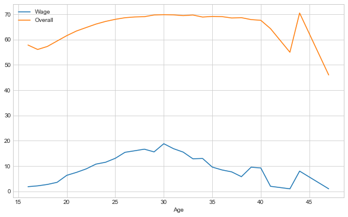

```python
# 'line' : line plot (default)

fifa.groupby(by='Age').mean()[['Wage', 'Overall']].plot.line(figsize=(10,6))
```

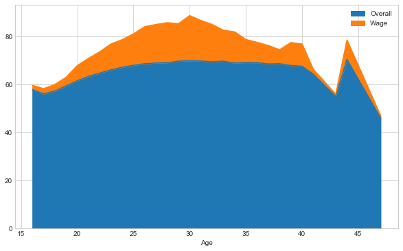

```python
# 'area' : area plot

fifa.groupby(by='Age').mean()[['Overall', 'Wage']].plot.area(figsize=(10,6))
```

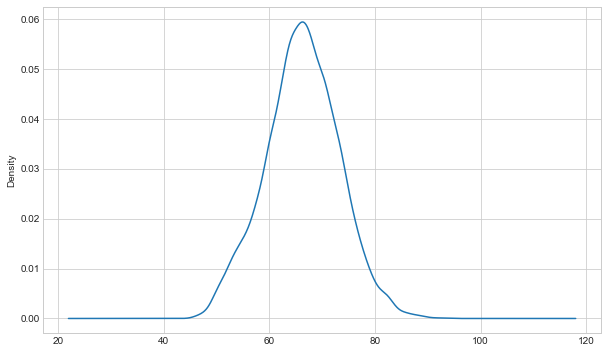

```python
# 'kde' : Kernel Density Estimation plot

fifa.loc[0:]['Overall'].plot(kind='kde', figsize=(10,6))
```

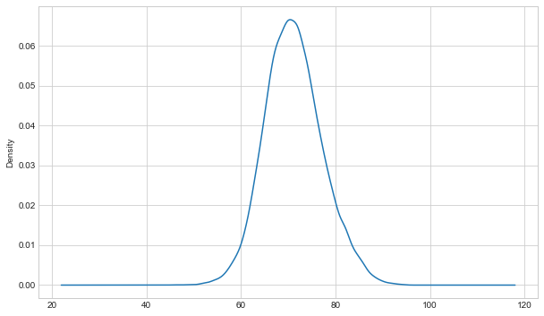

```python
# 'density' : same as 'kde'

fifa.loc[0:]['Potential'].plot(kind='density', figsize=(10,6))
```

# Bar, Barh, Pie

- Good for nominal and small ordinal categorical data.
- Bar graphs are used to compare things between different groups

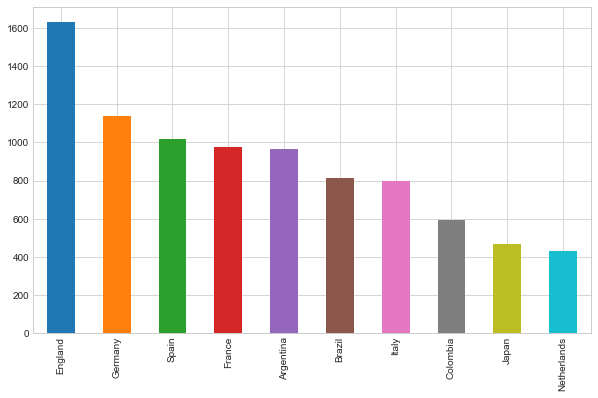

```python
# 'bar' : vertical bar plot

fifa['Nationality'].value_counts().head(10).plot.bar(figsize=(10,6))
```

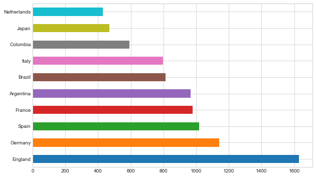

```python
# 'barh' : horizontal bar plot

fifa['Nationality'].value_counts().head(10).plot.barh(figsize=(10,6))
```

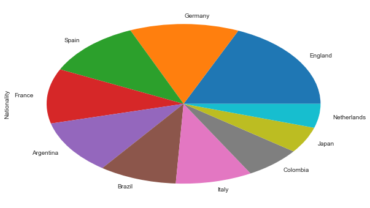

```python
# 'pie' : pie plot

fifa['Nationality'].value_counts().head(10).plot.pie(figsize=(10,6))
```

### Histogram

- Good for interval data.

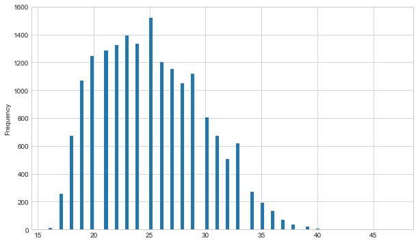

```python
# 'hist' : histogram

fifa["Age"].plot.hist(bins=100, figsize=(10,6))
```

### Boxplot

- To visualize the distribution of values within each column.

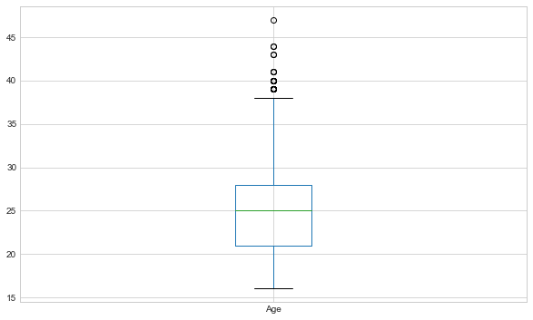

```python
# 'box' : boxplot

fifa['Age'].plot.box(figsize=(10,6))
```

### Bivariate

- 'scatter' : scatter plot
- 'hexbin' : hexbin plot

### Scatter

A simple scatter plot simply maps each variable of interest to a point in two-dimensional space.

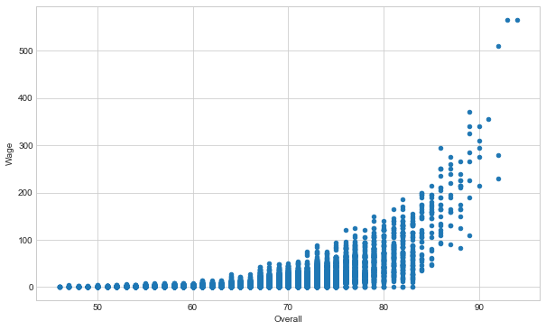

```python
# 'scatter' : scatter plot

fifa.plot(kind='scatter', x='Overall', y='Wage', figsize=(10,6))
```

### Hexbin

- A hex plot aggregates points in space into hexagons, and then colors those hexagons based on the values within them

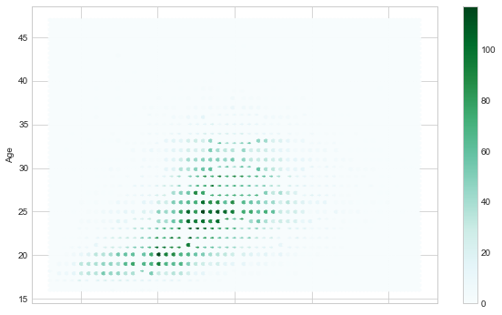

```python
# 'hexbin' : hexbin plot

fifa.plot(kind='hexbin', x='Overall', y='Age', figsize=(10,6), grid=15)
```

### Multivariate

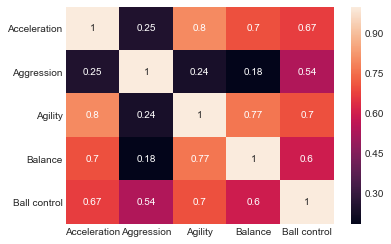

```python
# Heatmap

f = (
    fifa.loc[:, ['Acceleration', 'Aggression', 'Agility', 'Balance', 'Ball control']]
        .applymap(lambda v: int(v) if str.isdecimal(v) else np.nan)
        .dropna()
).corr()

sns.heatmap(f, annot=True)
```